# tp1-sol

Ce TP nécessite un environnement contenant:

- Python (>= 3.6)
- scikit-learn (0.24.2)
- numpy (1.19) (vient automatiquement avec scikit-learn)
- matplotlib
- pandas
- jupyter
- ipykernel

Si vous n'avez pas un tel environnement, dans un invite de commandes Anaconda ou MiniConda, tapez:

conda create --name env_rl_tp python=3.6 scikit-learn=0.24.2 matplotlib pandas ipykernel jupyter

# TP1

L'objectif de ce TP est, dans un premier temps, de se familiariser avec la régression linéaire (RL) dans un cadre prédictif. Nous allons utiliser le jeu de données "Boston Houssing Prices" présenté en cours.

Dans un second temps, nous aborderons une des limites de la régression linéaire: la dimension i.e. ce qui se passe quand le nombre de variables $X_1, \dots, X_d$ devient très grand, ce qui nous amènera au second cours.

## Partie I

Utilisation de la RL pour la prédiction de prix de biens immobiliers à partir. Le jeu deu de données en question est disponible dans la librairie Scikit-learn.

D'abord, on importe les modules python dont nous aurons besoin:

### Préliminaires

```python
from sklearn.datasets import load_boston
from sklearn.linear_model import LinearRegression
from sklearn.metrics import r2_score
from sklearn.model_selection import cross_validate
import matplotlib.pyplot as plt
import numpy as np
from scipy.stats import describe as sp_describe
import pandas as pd
```

On importe le jeu de données "Boston Houssing Prices" avec Scikit-learn dans deux variables: X pour les mesures des variables prédictives et y pour celles de la variable cible.

```python
dataset = load_boston()
var_names = dataset.feature_names
X_df, y_df = pd.DataFrame(dataset.data, columns = var_names), pd.DataFrame(dataset.target, columns=['target'])
X, y = np.array(X_df), np.array(y_df) # copy in numpy.array format
n, d = X.shape
```

Avant d'effectuer un apprentissage de modèle prédictif, il est FONDAMENTAL d'analyser les données en question (statistique descriptive). Il faut visualiser $x_{i1} \dots x_{id}$ indépendamment des $y_i$ (boxplot, histogramme), puis regarder quelques caractéristiques statistiques (moyennes, min, max, médiane, etc), ensuite regarder la relation en les observations de la cible $y_i$ et des prédicteurs. C'est cette analyse qui nous amène à postuler le modèle linénaire comme bon candidat prédictif.

Cette analyse préliminaire peut être longue et est hors-scope du TP. Ici, on "sait que le modèle linéaire convient" (on n'en n'est jamais sûr...). On va némanmoins extraire quelques statistiques:

```python
X_df.describe()
```

|  | CRIM | ZN | INDUS | CHAS | NOX | RM | AGE | DIS | RAD | TAX | PTRATIO | B | LSTAT |
| --- | --- | --- | --- | --- | --- | --- | --- | --- | --- | --- | --- | --- | --- |
| count | 506.000000 | 506.000000 | 506.000000 | 506.000000 | 506.000000 | 506.000000 | 506.000000 | 506.000000 | 506.000000 | 506.000000 | 506.000000 | 506.000000 | 506.000000 |
| mean | 3.613524 | 11.363636 | 11.136779 | 0.069170 | 0.554695 | 6.284634 | 68.574901 | 3.795043 | 9.549407 | 408.237154 | 18.455534 | 356.674032 | 12.653063 |
| std | 8.601545 | 23.322453 | 6.860353 | 0.253994 | 0.115878 | 0.702617 | 28.148861 | 2.105710 | 8.707259 | 168.537116 | 2.164946 | 91.294864 | 7.141062 |
| min | 0.006320 | 0.000000 | 0.460000 | 0.000000 | 0.385000 | 3.561000 | 2.900000 | 1.129600 | 1.000000 | 187.000000 | 12.600000 | 0.320000 | 1.730000 |
| 25% | 0.082045 | 0.000000 | 5.190000 | 0.000000 | 0.449000 | 5.885500 | 45.025000 | 2.100175 | 4.000000 | 279.000000 | 17.400000 | 375.377500 | 6.950000 |
| 50% | 0.256510 | 0.000000 | 9.690000 | 0.000000 | 0.538000 | 6.208500 | 77.500000 | 3.207450 | 5.000000 | 330.000000 | 19.050000 | 391.440000 | 11.360000 |
| 75% | 3.677083 | 12.500000 | 18.100000 | 0.000000 | 0.624000 | 6.623500 | 94.075000 | 5.188425 | 24.000000 | 666.000000 | 20.200000 | 396.225000 | 16.955000 |
| max | 88.976200 | 100.000000 | 27.740000 | 1.000000 | 0.871000 | 8.780000 | 100.000000 | 12.126500 | 24.000000 | 711.000000 | 22.000000 | 396.900000 | 37.970000 |

Visualisons la relation entre la cible (ordonnée) et les prédicteurs (abscisse):

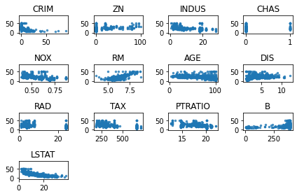

```python
for j in range(d):
    plt.subplot(4, 4, j+1)
    plt.scatter(X[:, j], y, alpha=0.75, s=6)
    plt.title(var_names[j])
    plt.ylim(-5.0, 90.0)

plt.tight_layout()
```

### Apprentissage des paramètres $w_{1}, \dots, w_{d}$

#### Estimateur "brute"

On va estimer les paramtères du modèle en utilisant les opérateurs matriciels de NumPy, puis on utilisera et comperera les résultats avec un estimateur de Scikit-learn.

1- Ecrire une fonction qui prédit la variable cible $y_{i}^{pred}$ à partir de paramtères et d'une observation $x_{i}$ donnés.

```python
def pred_y(x, beta):
    """prediction de y selon x, beta"""
    pred = x @ beta
    return pred
```

2- Ecrire une fonction qui prend en entrée:

- un ensemble d'observations de la variable cible $y_{1}, \dots y_{i}, \dots$
- les prédictions associées $y_{1}^{pred} = \sum_j w_{j} x_{1j}, \dots y_{i}^{pred} = \sum_{j} w_{j} x_{ij}, \dots$

et retourne en sortie l'erreur quadratique moyenne.

```python
def err_quad(y_obs, y_pred):
    """erreur quadratique moyenne"""
    n = len(y_obs)
    e_i = y_obs - y_pred
    err_quad = np.square(e_i)
    res = 0.5 * (1/n) * np.sum(err_quad)
    return res
```

3- Ecrire une fonction estime les paramètres $w_{1}, \dots, w_{d}$, à partir des observations $\{ y_i, x_i \}_{i \leq n}$ de façon à minimiser l'erreur quadratique moyenne.

```python
def learn_w(X, Y):
    """solution des moindres carrés linéaires"""
    w_hat = np.linalg.inv(X.T @ X) @ X.T @ Y
    return w_hat
```

4- Ecrire une fonction qui séparer les observations du jeu de données aléatoirement en un ensemble d'entraînement et un ensemble de test.

```python
np.random.seed(3011)
def split_train_test(X, Y, ratio=0.7):
    """train/test split"""
    n = len(Y)
    n_tr = int(ratio * n)
    idx_train = np.random.randint(low=0, high=n-1, size=n_tr-1) # indices python commence à 0.
    idx_test = np.setdiff1d(ar1=np.arange(0, n-1), ar2=idx_train)
    idx_train, idx_test = list(idx_train), list(idx_test)
    Y_train, X_train = Y[idx_train], X[idx_train, :]
    Y_test, X_test = Y[idx_test], X[idx_test, :]
    # centrage des données:
    X_mean, y_mean = X_train.mean(axis=0), Y_train.mean()
    X_train -= X_mean
    X_test -= X_mean
    Y_train -= y_mean
    Y_test -= y_mean
    return X_train, X_test, Y_train, Y_test
```

5- Utiliser les fonctions précédentes pour:

- apprendre un modèle linéaire sur le jeu de données fourni,
- évaluer l'erreur de généralisation du modèle appris sur un jeu de données test (aussi "appelée erreur de test"),
- évaluer aussi l'erreur d'entraînement.

```python
# division aléatoire entraînement/test
X_tr, X_ts, y_tr, y_ts = split_train_test(X=X, Y=y, ratio=0.65)
```

```python
# apprentissge des paramètres sur l'ensemble d'entraînement
w_hat = learn_w(Y=y_tr, X=X_tr)
w_hat.shape
print("Paramètres du modèle: {}".format(w_hat))
```

```
Paramètres du modèle: [[-6.40099363e-02]
 [ 2.36867182e-02]
 [-7.43159414e-02]
 [ 6.45673648e-01]
 [-1.59311919e+01]
 [ 4.57669281e+00]
 [-4.41199094e-02]
 [-1.37734857e+00]
 [ 2.11808968e-01]
 [-1.02805265e-02]
 [-9.63335144e-01]
 [ 6.26877791e-03]
 [-2.63869840e-01]]
```

```python
# evaluation de l'erreur de prédiction moyenne sur l'ensemble de test
y_pred_ts = pred_y(X_ts, w_hat)
err_test = err_quad(y_ts, y_pred_ts)
y_pred_tr = pred_y(X_tr, w_hat)
err_train = err_quad(y_tr, y_pred_tr)
print("Erreur de test = {}".format(err_test))
print("Erreur d'entraînement = {}".format(err_train))
```

```
Erreur de test = 15.213481293930933
Erreur d'entraînement = 8.737981324711564
```

Pour avoir une meilleure estimation de l'erreur de généralisation qu'avec une seule séparation entraînement/test, on répètre la procédure plusieurs fois puis on calcul la moyenne des erreurs de généralisations. Cette procédure s'appelle la "validation croisée".

6- Ecrire une fonction qui réalise la validation croisée, puis donnez une estimation de l'erreur de généralisation.

```python
def cv_rl(X, y, n_cv=10):
    err_cv = np.empty(shape=n_cv)
    for k in range(n_cv):
        X_tr, X_ts, y_tr, y_ts = split_train_test(X=X, Y=y, ratio=0.80)
        w_hat_k = learn_w(Y=y_tr, X=X_tr)
        pred = pred_y(X_ts, w_hat_k)
        err_cv[k] = err_quad(y_obs=y_ts, y_pred=pred)

    return err_cv
```

```python
# np.random.seed(3011)
n_cv = 20
err_cv10 = cv_rl(X=X, y=y, n_cv=n_cv)
```

```python
print("Erreur de généralisation sur {} répétitions: {}".format(n_cv, err_cv10.mean()))
print("écart-type: {}".format(err_cv10.std()))
```

```
Erreur de généralisation sur 20 répétitions: 12.705511133320206
écart-type: 2.137724088545251
```

#### Comparaison avec un estimateur de Scikit-learn

Scikit-learn fourni un estimateur de modèle linéaire optimisé (vérification du format d'entrée, solveur optimisé, etc). Nous allons l'utiliser et comparer les résultats.

```python
np.random.seed(3011)
# instatiation d'un objet LinearRegression
rl_skl = LinearRegression()
# estimation
rl_skl.fit(X, y)
print(rl_skl.coef_)
```

```
[[-1.08011358e-01  4.64204584e-02  2.05586264e-02  2.68673382e+00
  -1.77666112e+01  3.80986521e+00  6.92224640e-04 -1.47556685e+00
   3.06049479e-01 -1.23345939e-02 -9.52747232e-01  9.31168327e-03
  -5.24758378e-01]]
```

```python
w_hat = learn_w(X=X - X.mean(axis=0), Y=y - y.mean())
print(w_hat)
```

```
[[-1.08011358e-01]
 [ 4.64204584e-02]
 [ 2.05586264e-02]
 [ 2.68673382e+00]
 [-1.77666112e+01]
 [ 3.80986521e+00]
 [ 6.92224640e-04]
 [-1.47556685e+00]
 [ 3.06049479e-01]
 [-1.23345939e-02]
 [-9.52747232e-01]
 [ 9.31168327e-03]
 [-5.24758378e-01]]
```

Vérifier que les deux estimations sont égales.

## Partie II

### Etude de l'effet dimension sur l'apprentissage des paramètres

Jusqu'ici on a considéré un nombre de variables faible et un nombre d'observations "important". Souvent, et c'est de plus en plus fréquent avec l'ère "big data", le nombre de variables $d$ est grand devant le nombre d'obersvations $n$. Cela pose des souci de calcul, $\hat{w}$ est très couteûx à calculer, d'incertitude de prédiction et également d'analyse du modèle appris. Si les données comportent, par exemple, plus de $d=500$ variables, il y a de grande chance que

- certaines soient totalement décorrélées de la variable cible,
- certaines sont fortement corrélées à d'autres variables predictives.

Dans le premier cas, on a un souci d'interprétabilité (utilisation de variables à tort), on aimerait supprimer ces variables "inutiles". Dans le deuxième cas, la prédiction du modèle appris deviendra plus incertaine, puisque le coefficient d'une variable corrélée à d'autre prédicteurs ne sera jamais nul, on ne sait pas vraiment si il a un petit effet sur la prédiction ou bien si cela dû à l'aléa présent dans les données.

On appelle ce phénomène la "malédiction de la dimensionalité".

Regardons cela empiriquement sur des données artificielles.

```python
# nettoyage de l'espace des variables
%reset
```

```python
from sklearn.linear_model import LinearRegression
from sklearn.datasets import make_regression
from sklearn.metrics import r2_score, mean_squared_error
from sklearn.model_selection import cross_val_score
import numpy as np
from matplotlib import pyplot as plt
```

```python
n = 200
d = 250
d_util = 100
X, y, w_true = make_regression(n_samples=n, n_features=d, n_informative=d_util, coef=True, random_state=3012)
idx_util = list(np.where(w_true != 0.0)[0])
idx_nonutil = list(np.where(w_true == 0.0)[0])
```

```python
err_d = np.empty(d)
std_d = np.empty(d)

for j in range(d):
    rl_hd = LinearRegression()
    if j < d_util:
        # erreur de généralisation du modèle appris avec des variables utiles pour prédire y
        scores = cross_val_score(rl_hd, X[:, idx_util[:(j+1)]], y,
                                scoring="neg_mean_squared_error", cv=5)
    else:
        # erreur de généralisation du modèle appris avec toutes les variables utiles
        # et d'autes inutiles pour prédire y
        scores = cross_val_score(rl_hd, X[:, idx_util + idx_nonutil[:(j+1-d_util)]], y,
                                scoring="neg_mean_squared_error", cv=5)
    err_d[j] = -scores.mean()
    std_d[j] = scores.std()
```

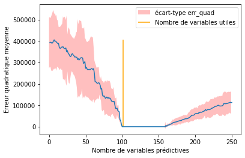

```python
plt.plot(np.arange(0, d)+1, err_d)
plt.fill_between(np.arange(0, d),
    err_d + 2*std_d,
    err_d - 2*std_d,
    facecolor='red', alpha=0.25, label="écart-type err_quad")

plt.vlines(x=d_util+1, ymin=err_d.min(), ymax=err_d.max(),
    colors='orange', label="Nombre de variables utiles")

plt.xlabel("Nombre de variables prédictives")
plt.ylabel("Erreur quadratique moyenne")
plt.legend()
```